# Praktikum 2 Regresi Data Pharma Sales tahun 2014-2019

# Pemanggilan *Packages*

```r
library(dplyr)
library(TTR)
library(forecast)
library(lmtest) #digunakan untuk uji formal pendeteksian autokorelasi
library(orcutt) #untuk membuat model regresi Cochrane-Orcutt
library(HoRM) #untuk membuat model regresi Hildreth-Lu
```

# Impor Data

Data yang digunakan adalah data Pharma Sales tahun 2014-2019.

```r
#install.packages("rio") #install jika belum ada
library(rio)
datapharma <- import("https://raw.githubusercontent.com/aidara11/mpdw/main/Pertemuan%202/salesmonthly.csv")
```

# Eksplorasi Data

```r
View(datapharma)    #melihat data
str(datapharma)     #struktur data
```

```
## 'data.frame':    70 obs. of  9 variables:
##  $ datum: IDate, format: "2014-01-31" "2014-02-28" ...
##  $ M01AB: num  128 133 137 113 102 ...
##  $ M01AE: num  99.1 126.1 93 89.5 119.9 ...
##  $ N02BA: num  152 177 148 131 132 ...
##  $ N02BE: num  878 1002 779 698 629 ...
##  $ N05B : num  354 347 232 209 270 323 348 420 399 472 ...
##  $ N05C : num  50 31 20 18 23 23 21 29 14 30 ...
##  $ R03  : num  112 122 112 97 107 57 61 37 115 182 ...
##  $ R06  : num  48.2 36.2 85.4 73.7 123.7 ...
```

```r
dim(datapharma)     #dimensi data
```

```
## [1] 70  9
```

## Menamakan Peubah

```r
y <- datapharma[,9]
x1 <- datapharma[,2]
x2 <- datapharma[,3]
x3 <- datapharma[,4]
x4 <- datapharma[,5]

data <- cbind(y, x1, x2, x3, x4)
data <- as.data.frame(data)
```

## Ringkasan data peubah respon

```r
summary(y)
```

```
##    Min. 1st Qu.  Median    Mean 3rd Qu.    Max.
##    0.00   49.88   74.10   86.66  119.81  213.04
```

## Histogram

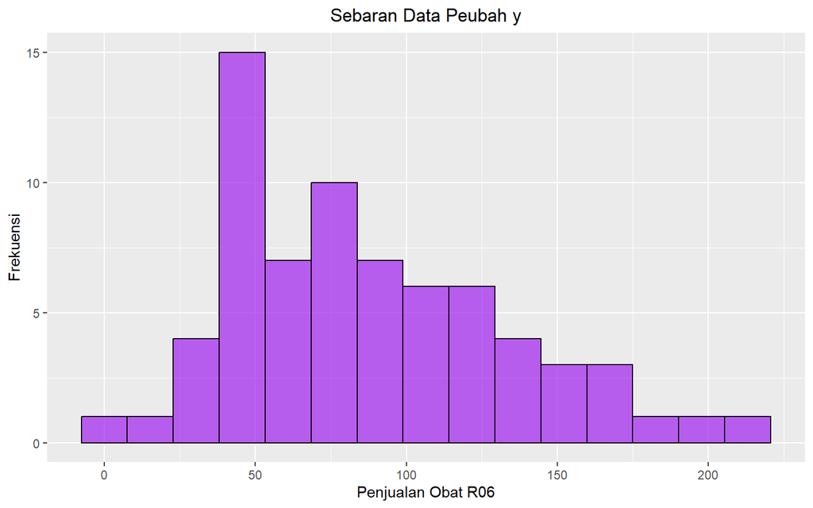

```r
# Peubah Respon dan Peubah Penjelas

library(ggplot2)
ggplot(data, aes(x=y)) +
  geom_histogram(fill="purple", bins=15, color='black', alpha=0.7) +
    ggtitle("Sebaran Data Peubah y") + #Title
  theme(plot.title = element_text(hjust = 0.5)) + #Title Position +
  ylab("Frekuensi")+xlab("Penjualan Obat R06")
```

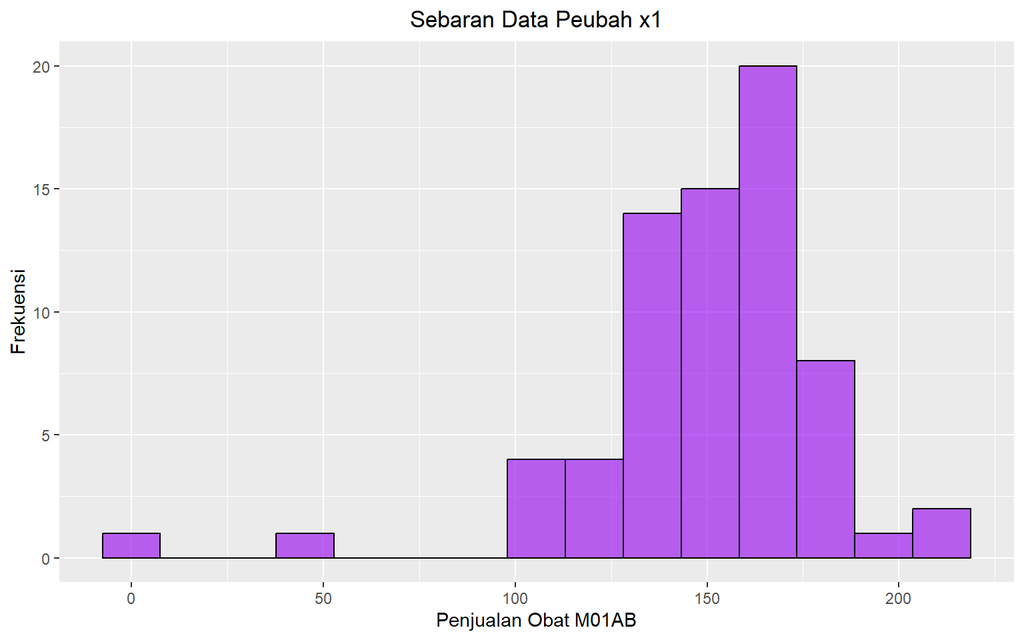

```r
ggplot(data, aes(x=x1)) +
  geom_histogram(fill="purple", bins=15, color='black', alpha=0.7) +
    ggtitle("Sebaran Data Peubah x1") + #Title
  theme(plot.title = element_text(hjust = 0.5)) + #Title Position +
  ylab("Frekuensi")+xlab("Penjualan Obat M01AB")
```

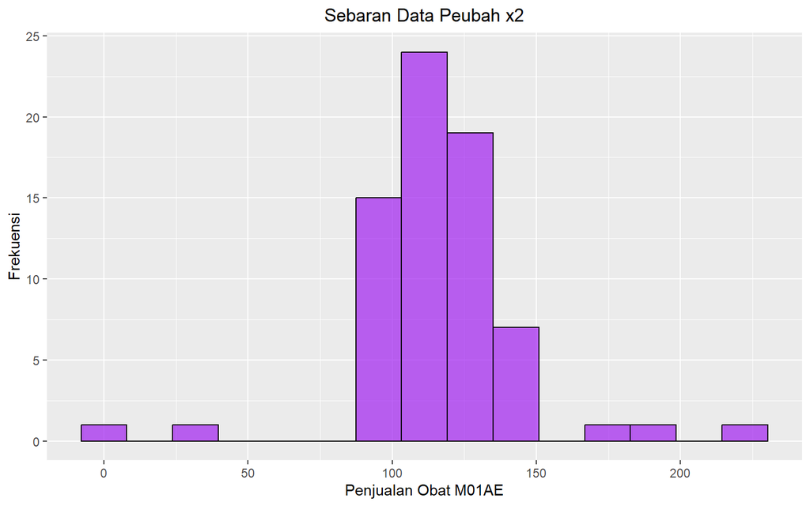

```r
ggplot(data, aes(x=x2)) +
  geom_histogram(fill="purple", bins=15, color='black', alpha=0.7) +
    ggtitle("Sebaran Data Peubah x2") + #Title
  theme(plot.title = element_text(hjust = 0.5)) + #Title Position +
  ylab("Frekuensi")+xlab("Penjualan Obat M01AE")
```

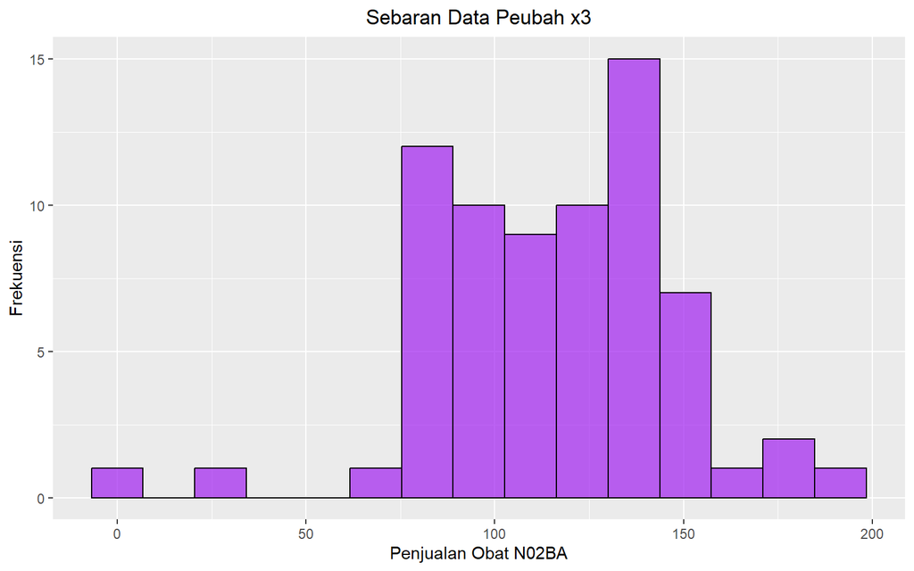

```r
ggplot(data, aes(x=x3)) +
  geom_histogram(fill="purple", bins=15, color='black', alpha=0.7) +
    ggtitle("Sebaran Data Peubah x3") + #Title
  theme(plot.title = element_text(hjust = 0.5)) + #Title Position +
  ylab("Frekuensi")+xlab("Penjualan Obat N02BA")
```

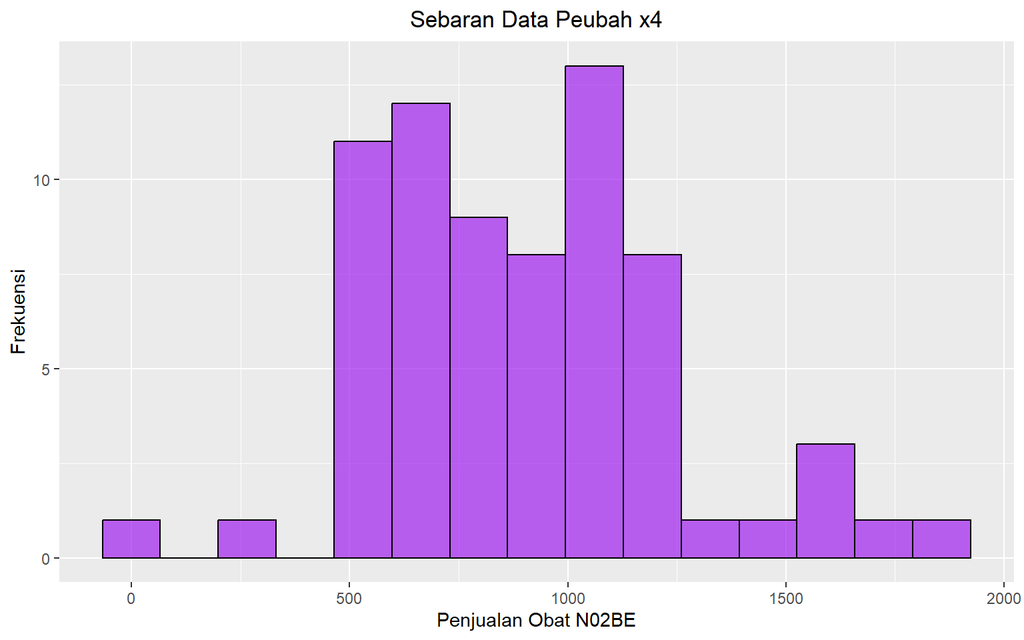

```r
ggplot(data, aes(x=x4)) +
  geom_histogram(fill="purple", bins=15, color='black', alpha=0.7) +
    ggtitle("Sebaran Data Peubah x4") + #Title
  theme(plot.title = element_text(hjust = 0.5)) + #Title Position +
  ylab("Frekuensi")+xlab("Penjualan Obat N02BE")
```

## Matriks Korelasi

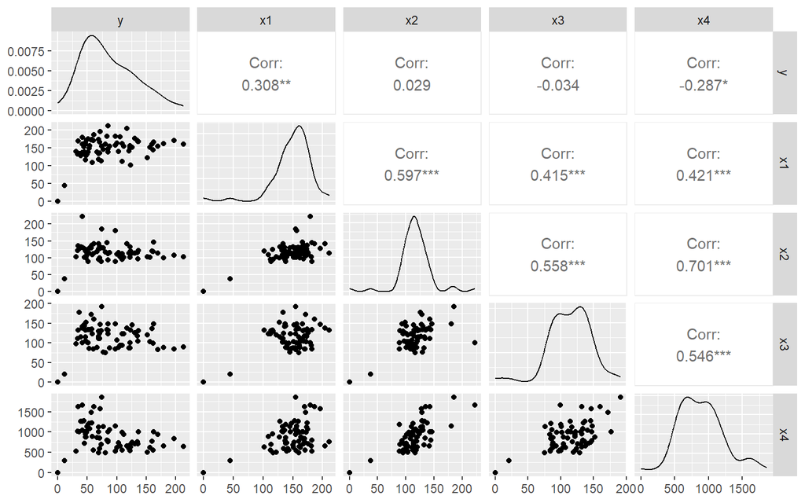

```r
library(ggplot2)
library(GGally)
sample_data <- data.frame(y, x1, x2, x3, x4)
ggpairs(sample_data)
```

Setalah mengetahui adanya hubungan antar dua peubah, maka model regresi dapat ditentukan.

# Regresi

```r
#Pembuatan Model Regresi
#model regresi
model<- lm(y~x1+x2+x3+x4, data = datapharma)
summary(model)
```

```
##
## Call:
## lm(formula = y ~ x1 + x2 + x3 + x4, data = datapharma)
##
## Residuals:
##     Min      1Q  Median      3Q     Max
## -75.369 -27.167  -3.581  22.357 103.234
##
## Coefficients:
##             Estimate Std. Error t value Pr(>|t|)
## (Intercept) 25.14448   25.15308   1.000 0.321183
## x1           0.65941    0.18734   3.520 0.000794 ***
## x2           0.29474    0.27278   1.081 0.283906
## x3           0.01718    0.18900   0.091 0.927848
## x4          -0.08258    0.02012  -4.104 0.000116 ***
## ---
## Signif. codes:  0 '***' 0.001 '**' 0.01 '*' 0.05 '.' 0.1 ' ' 1
##
## Residual standard error: 38.98 on 65 degrees of freedom
## Multiple R-squared:  0.3194, Adjusted R-squared:  0.2775
## F-statistic: 7.627 on 4 and 65 DF,  p-value: 4.215e-05
```

Model yang dihasilkan adalah
$$y=25.144+0.6594x_1+0.2947x_2+0.01718x_3-0.0825x_4$$
Berdasarkan ringkasan model dapat diketahui bahwa hasil uji F memiliki *p-value* < $\alpha$ (5%). Artinya, minimal terdapat satu variabel yang berpengaruh nyata terhadap model. Hasil uji-t parsial parameter regresi, yaitu koefisien regresi untuk x1 dan x4 juga menunjukkan hal yang sama, yaitu memiliki *p-value* < $\alpha$ (5%) sehingga nyata dalam taraf 5%. Selanjutnya dapat dilihat juga nilai $R^2=0.3194$. Artinya, sebesar 31.94% keragaman nilai peubah y (penjualan obat R06) dapat dijelaskan oleh peubah x (M01AB, M01AE, N02BA, N02BE). Hasil ini menunjukkan hasil yang kurang bagus, sehingga belum mendapatkan hasil terbaik. Selanjutnya, kita perlu melakukan uji terhadap sisaannya seperti berikut ini.

## Diagnostik secara Eksploratif

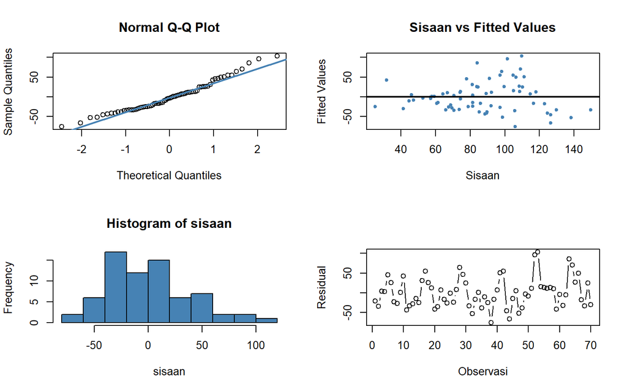

```r
#sisaan dan fitted value
sisaan <- residuals(model)
fitValue <- predict(model)

#Diagnostik dengan eksploratif
par(mfrow = c(2,2))
qqnorm(sisaan)

qqline(sisaan, col = "steelblue", lwd = 2)

plot(fitValue, sisaan, col = "steelblue", pch = 20, xlab = "Sisaan", ylab = "Fitted Values", main = "Sisaan vs Fitted Values")
abline(a = 0, b = 0, lwd = 2)
hist(sisaan, col = "steelblue")

#plot sisaan vs urutan (sisaan saling bebas)
plot(x = 1:dim(data)[1],
     y = model$residual,
     type = 'b',
     ylab = "Residual",
     xlab = "Observasi")
```

Dua plot di samping kiri digunakan untuk melihat apakah sisaan menyebar normal. Normal Q-Q Plot dan histogram dari sisaan di atas menunjukkan bahwa sisaan cenderung menyebar normal. Selanjutnya, dua plot di samping kanan digunakan untuk melihat autokorelasi. Plot Sisaan vs *Fitted Value* dan Plot Sisaan vs *Order* menunjukkan adanya pola pada sisaan. Untuk lebih lanjut akan digunakan uji formal melihat normalitas sisaan dan plot ACF dan PACF untuk melihat apakah ada autokorelasi atau tidak.